# Womens Clothing E-Commerce Reviews

This is a Women’s Clothing E-Commerce dataset revolving around the reviews written by customers. Its nine supportive features offer a great environment to parse out the text through its multiple dimensions. Because this is real commercial data, it has been anonymized, and references to the company in the review text and body have been replaced with “retailer”.  
The dataset is found on [Kaggle.com : "Women's E-Commerce Clothing Reviews"](https://www.kaggle.com/nicapotato/womens-ecommerce-clothing-reviews/home).

# 1.0 Packages

```python
#Import packages
import pandas as pd
import numpy as np
import matplotlib.pyplot as plt
import seaborn as sns
import matplotlib.mlab as mlab
%matplotlib inline
from matplotlib.gridspec import GridSpec
```

# 2.0 Exploriatory Data Analysis

## 2.1 Overview

```python
#download the file
df = pd.read_csv('Womens Clothing E-Commerce Reviews.csv')
```

```python
df.head()
```

[output not shown]

```python
#Quick change: rename "Unamed: 0" to User and remove space in clothing ID
df.rename(columns={"Unnamed: 0": "UserID", "Clothing ID": "ClothingID"}, inplace = True);
```

```python
df.head(2)
```

|  | UserID | ClothingID | Age | Title | Review Text | Rating | Recommended IND | Positive Feedback Count | Division Name | Department Name | Class Name |
| --- | --- | --- | --- | --- | --- | --- | --- | --- | --- | --- | --- |
| 0 | 0 | 767 | 33 | NaN | Absolutely wonderful - silky and sexy and comf... | 4 | 1 | 0 | Initmates | Intimate | Intimates |
| 1 | 1 | 1080 | 34 | NaN | Love this dress! it's sooo pretty. i happene... | 5 | 1 | 4 | General | Dresses | Dresses |

```python
df.shape
```

```
(23486, 11)
```

```python
df.dtypes
```

```
UserID                      int64
ClothingID                  int64
Age                         int64
Title                      object
Review Text                object
Rating                      int64
Recommended IND             int64
Positive Feedback Count     int64
Division Name              object
Department Name            object
Class Name                 object
dtype: object
```

```python
df.describe()
```

|  | UserID | ClothingID | Age | Rating | Recommended IND | Positive Feedback Count |
| --- | --- | --- | --- | --- | --- | --- |
| count | 23486.000000 | 23486.000000 | 23486.000000 | 23486.000000 | 23486.000000 | 23486.000000 |
| mean | 11742.500000 | 918.118709 | 43.198544 | 4.196032 | 0.822362 | 2.535936 |
| std | 6779.968547 | 203.298980 | 12.279544 | 1.110031 | 0.382216 | 5.702202 |
| min | 0.000000 | 0.000000 | 18.000000 | 1.000000 | 0.000000 | 0.000000 |
| 25% | 5871.250000 | 861.000000 | 34.000000 | 4.000000 | 1.000000 | 0.000000 |
| 50% | 11742.500000 | 936.000000 | 41.000000 | 5.000000 | 1.000000 | 1.000000 |
| 75% | 17613.750000 | 1078.000000 | 52.000000 | 5.000000 | 1.000000 | 3.000000 |
| max | 23485.000000 | 1205.000000 | 99.000000 | 5.000000 | 1.000000 | 122.000000 |

```python
#Look up a random review
df['Review Text'][90]
```

```
'I love cute summer dresses and this one, especially because it is made out of linen, is unique. it is very well-made with a design that is quite flattering. i am 5 foot 6 and a little curvy with a 38 c bust and i got a size 10. it fits well although it is difficult to zip up because the material ha…
```

The sample review text above shows that we can extract certain details about the users such as:

- measurements (height, bust size)
- recurring words
- positive/negative adjectives (perfect, unique, cute)
- verbs (love)
- use of punctuation (!,?, !?, -, etc...)

```python
#Unique entry in each column
df.nunique()
```

```
UserID                     23486
ClothingID                  1206
Age                           77
Title                      13993
Review Text                22634
Rating                         5
Recommended IND                2
Positive Feedback Count       82
Division Name                  3
Department Name                6
Class Name                    20
dtype: int64
```

From the information above assume that all the user entries are unique individuals.

```python
# Null Entries
df.isna().sum()
```

```
UserID                        0
ClothingID                    0
Age                           0
Title                      3810
Review Text                 845
Rating                        0
Recommended IND               0
Positive Feedback Count       0
Division Name                14
Department Name              14
Class Name                   14
dtype: int64
```

```python
#List unique division names
df['Division Name'].value_counts()
```

```
General           13850
General Petite     8120
Initmates          1502
Name: Division Name, dtype: int64
```

```python
#Number of items with no division
df['Division Name'].isnull().sum()
```

```
14
```

```python
# List department names
df['Department Name'].value_counts()
```

```
Tops        10468
Dresses      6319
Bottoms      3799
Intimate     1735
Jackets      1032
Trend         119
Name: Department Name, dtype: int64
```

```python
#List class names
df['Class Name'].value_counts()
```

```
Dresses           6319
Knits             4843
Blouses           3097
Sweaters          1428
Pants             1388
Jeans             1147
Fine gauge        1100
Skirts             945
Jackets            704
Lounge             691
Swim               350
Outerwear          328
Shorts             317
Sleep              228
Legwear            165
Intimates          154
Layering           146
Trend              119
Casual bottoms       2
Chemises             1
Name: Class Name, dtype: int64
```

## 2.2 Visualizations

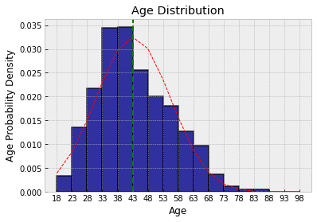

```python
#Create bin to store ages
age_bin= np.arange(18, 100, 5)
#Average age
age_avg = np.average(df['Age'])
#age standard devation
age_std = np.std(df['Age'])

#Create histogram
plt.hist(df['Age'], bins = age_bin, alpha = 0.8, edgecolor='black', linewidth =1.5, color ='darkblue', density= 1)

#Add a fit
y = mlab.normpdf( age_bin, age_avg, age_std)
l = plt.plot(age_bin, y, 'r--', linewidth=1)

#Set x axis ticks to match bins
plt.xticks(age_bin)

#Add labels and title
plt.xlabel("Age")
plt.ylabel("Age Probability Density")
plt.title("Age Distribution")

#Add average line
plt.axvline(age_avg, color='green', linestyle = 'dashed', linewidth= 2)

#Use grey background
plt.style.use('bmh')

#Display histogram
plt.show()
```

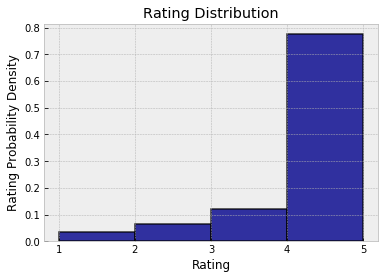

```python
#Create bin for rating
rating_bin = np.arange(1, 6, 1)

#Create histogram
plt.hist(df['Rating'], bins = rating_bin, alpha = 0.8, edgecolor='black', linewidth =1.5, color ='darkblue', density= 1)

#Add labels and title
plt.xlabel("Rating")
plt.ylabel("Rating Probability Density")
plt.title("Rating Distribution")

#Set x axis ticks to match bins
plt.xticks(rating_bin)

plt.show()
```

The histogram is clearly skewed to the left. The majority of reviews are positive.

```python
#Create wedges and corresponding labels for column in dataframe.
def NameCount (df_in, column):
    #Store unique entries
    names = df_in[column].unique()
    #remove nans
    names = [x for x in names if str(x) != 'nan']
    #Create array to store values
    count = np.empty(len(names))
    #Store recurrence of each value
    for i in range(len(names)):
        count[i] = df[(df[column] == names[i])].shape[0]
    return names, count
```

```python
#Division
div_name, div_count = NameCount(df, 'Division Name')
#Department
dep_name, dep_count = NameCount(df, 'Department Name')
#Class
class_name, class_count = NameCount(df, 'Class Name')
```

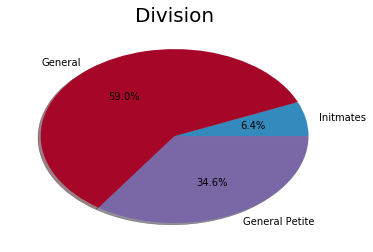

```python
plt.pie(div_count, labels=div_name, autopct='%1.1f%%', shadow=True, radius= 1)
plt.title("Division", fontsize = 20)
plt.show()
```

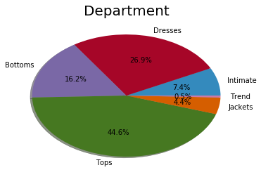

```python
plt.pie(dep_count, labels=dep_name, autopct='%1.1f%%', shadow=True, radius= 1)
plt.title("Department", fontsize = 20)
plt.show()
```

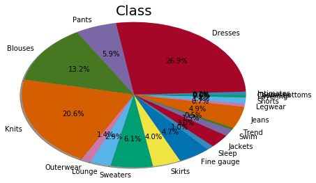

```python
plt.pie(class_count, labels=class_name, autopct='%1.1f%%', shadow=True, radius= 1.2)
plt.title("Class", loc = 'center', fontsize = 20)
plt.show()
```

# 3.0 Cleaning

```python
#Check for empty reviews
pd.isna(df['Review Text']).sum()
```

```
845
```

```python
#Drop all empty reviews
df_temp = df.dropna(subset=['Review Text', 'Department Name', 'Division Name', 'Class Name'])
```

```python
#Data Left
df_temp.shape[0] /df.shape[0]
```

```
0.9634675977177893
```

```python
#Reset index
df_index = df_temp.reset_index()
```

```python
#Check for empty reviews
for i in range(df_index.shape[0]):
    if pd.isna(df_index['Review Text'][i]) == True:
        print(i)
```

```python
#Store reviews in list
review_text = np.array(df_index['Review Text'])
```

```python
#Make all entires lower case
for i in range(len(review_text)):
    review_text[i] = review_text[i].lower()
```

```python
#Store department in list
department = np.array(df_index['Department Name'])
```

# 4.0 Word Cloud

This section is possible thanks to this [datacamp](https://www.datacamp.com/community/tutorials/wordcloud-python) tutorial.

```python
from PIL import Image
from wordcloud import WordCloud, STOPWORDS, ImageColorGenerator
from os import path
```

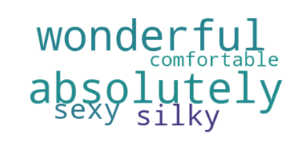

```python
#Try on the first review
word_cloud_0 = WordCloud(background_color="white", max_font_size= 100).generate(review_text[0])
#Display the image
plt.imshow(word_cloud_0, interpolation='bilinear')
plt.axis("off")
plt.show()
```

```python
#Combine all the reviews into one massive string
review_text_combined = " ".join(review for review in review_text)
print ("There are {} words in the combination of all reviews.".format(len(review_text_combined)))
```

```
There are 7009283 words in the combination of all reviews.
```

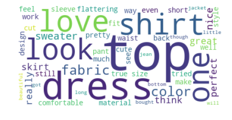

```python
# Create stopword list:
stopwords = set(STOPWORDS)
#For now let's only remove the
stopwords.update(["the"])

# Generate a word cloud image
wordcloud = WordCloud(stopwords=stopwords,
                      background_color="white",
                      width= 400, height = 200,
                      max_words=50).generate(review_text_combined)

# Display the generated image:
# the matplotlib way:
plt.imshow(wordcloud, interpolation='bilinear')
plt.axis("off")
plt.show()
```

Stock photo in code below taken from [publicdomainpictures.com](https://www.publicdomainpictures.net/en/view-image.php?image=229406&picture=young-woman-shopping).

```python
#Define mask for cloud
cloud_mask = np.array(Image.open("young_woman_shop.jpg"))
```

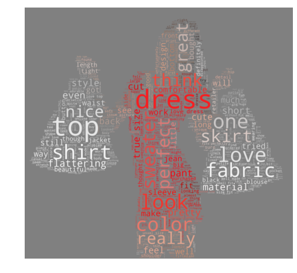

```python
wordcloud_shop = WordCloud(stopwords=stopwords,
                           background_color="grey",
                           mode="RGBA", max_words=1000,
                           mask=cloud_mask).generate(review_text_combined)

# create coloring from image
image_colors = ImageColorGenerator(cloud_mask)
plt.figure(figsize=[7,7])
plt.imshow(wordcloud_shop.recolor(color_func=image_colors), interpolation="bilinear")
plt.axis("off")

# store to file
#plt.savefig("img/woman_shop.png", format="png")

plt.show()
```

Looks ok but can be better. Let's take an image from [4vector.com](https://4vector.com/free-vector/women-shopping-vector-material-28292).  
Note that in both cases we have a white background.

```python
cloud_bw = np.array(Image.open("young_woman_2.jpg"))
```

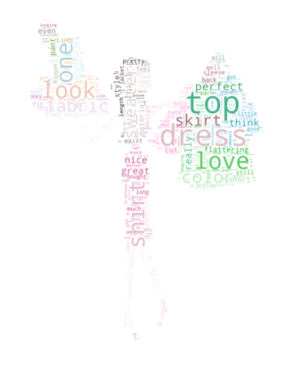

```python
# Generate a word cloud image
mask = cloud_bw
wordcloud_bw = WordCloud(stopwords=stopwords,
                         background_color="white",
                         mode="RGBA", max_words=1000,
                         mask=mask).generate(review_text_combined)

# create coloring from image
image_colors_bw = ImageColorGenerator(mask)
plt.figure(figsize=[7,7])
plt.imshow(wordcloud_bw.recolor(color_func=image_colors_bw), interpolation="bilinear")
plt.axis("off")

plt.show()
```

# 5.0 Predict Department Using NLP Classification

Use NLP tools to predict department based on reviews left by customers.

## 5.1 Extract Features

```python
from sklearn.model_selection import train_test_split
X_train, X_test, y_train, y_test = train_test_split(review_text, department, test_size=0.2, random_state=42)
```

```python
#Vectorize text
from sklearn.feature_extraction.text import CountVectorizer
#For the purpose of this exercise keep stop words
count_vect = CountVectorizer()
```

```python
#Apply on review text
X_train_counts = count_vect.fit_transform(X_train)
#See shape
X_train_counts.shape
```

```
(18102, 12874)
```

```python
#Fix weight of words based on length of text
from sklearn.feature_extraction.text import TfidfTransformer
tfidf_transformer = TfidfTransformer()
```

```python
X_train_tfidf = tfidf_transformer.fit_transform(X_train_counts)
X_train_tfidf.shape
```

```
(18102, 12874)
```

```python
#Repeat process for testing data
#Use transform instead of fit_transform because training dataset fixes the vocabulary

#Tokenize test set
X_test_counts = count_vect.transform(X_test)
#Normalize test set
X_test_tfidf = tfidf_transformer.transform(X_test_counts)
X_test_tfidf.shape
```

```
(4526, 12874)
```

## 5.2 Naive Bayes

```python
#Import MNB
from sklearn.naive_bayes import MultinomialNB
#Create classifier
clf_nb = MultinomialNB()
#Fit to training data
clf_nb.fit(X_train_tfidf, y_train)
```

```
MultinomialNB(alpha=1.0, class_prior=None, fit_prior=True)
```

```python
#Predict using Naive Bayes
nb_predict = clf_nb.predict(X_test_tfidf)
```

```python
#Get the score
np.mean(nb_predict == y_test)
```

```
0.6243923994697305
```

## 5.3 SGD Classifier

```python
#Import
from sklearn.linear_model import SGDClassifier
```

```python
#Create the classifer
clf_sgd= SGDClassifier(loss= 'hinge', penalty='l2', alpha= 1e-4, max_iter= 5, learning_rate='optimal')
#Fit to training data
clf_sgd.fit(X_train_tfidf, y_train)
```

```
SGDClassifier(alpha=0.0001, average=False, class_weight=None, epsilon=0.1,
       eta0=0.0, fit_intercept=True, l1_ratio=0.15,
       learning_rate='optimal', loss='hinge', max_iter=5, n_iter=None,
       n_jobs=1, penalty='l2', power_t=0.5, random_state=None,
       shuffle=True, tol=None, verbose=0, warm_start=False)
```

```python
#Predict using SVM
sgd_predict = clf_sgd.predict(X_test_tfidf)
```

```python
#Get the score
np.mean(sgd_predict == y_test)
```

```
0.8422448077772868
```

## 5.4 Grid Search Naive Bayes

```python
#import
from sklearn.model_selection import GridSearchCV
```

```python
#get list of NB params
clf_nb.get_params(deep=True)
```

```
{'alpha': 1.0, 'class_prior': None, 'fit_prior': True}
```

```python
#Use default parameters on scikit documentation
clf_nb.get_params()
```

```
{'alpha': 1.0, 'class_prior': None, 'fit_prior': True}
```

```python
#Set up parameters
#This will affect time to fit data
parameters_nb = {'alpha' : np.arange(0.1, 1, 0.1),
                 'fit_prior' : np.full((9,), True),
                 'class_prior' : np.full((9,), None)
                }
```

```python
#Create classifier
clf_nb_grid = GridSearchCV(clf_nb , parameters_nb)
```

```python
#Fit the data
clf_nb_grid.fit(X_train_tfidf, y_train)
```

```
GridSearchCV(cv=None, error_score='raise',
       estimator=MultinomialNB(alpha=1.0, class_prior=None, fit_prior=True),
       fit_params=None, iid=True, n_jobs=1,
       param_grid={'alpha': array([0.1, 0.2, 0.3, 0.4, 0.5, 0.6, 0.7, 0.8, 0.9]), 'fit_prior': array([ True,  True,  True,  True,  True,  True,  True,  True,  True]), 'class_prior': array([None, None, None, None, None, None, None, None, None], dtype=object)},
       pre_dispatch='2*n_jobs', refit=True, return_train_score='warn',
       scoring=None, verbose=0)
```

```python
#Predict using Gridsearch and NB
nb_grid_predict = clf_nb_grid.predict(X_test_tfidf)
```

```python
#Get the score
np.mean(nb_grid_predict == y_test)
```

```
0.7277949624392399
```

### 5.5 Manually Create Features (Brute Force)

Much thanks and credit and thanks to [Marwan H.](https://www.facebook.com/marwan.harajli) for explaining how tokenization can be applied to strings

```python
#import module
import re
```

```python
len(review_text)
```

```
22628
```

```python
#Create the metric space by extracting all the words, unique and duplicate, from the review text.
#The text is already lower case from section 3.0

#Create an empty array to store in the words
all_words = []

#Store all the words
for i in range(len(review_text)):
    wordlist = re.sub("[^\w]", " ", str(review_text[i])).split()
    for j in range (len(wordlist)):
        all_words.append(wordlist[j])
```

```python
#Drop the duplicates and make it iterable
all_words = list(set(all_words))
```

```python
#Create the feature space


n_observations = len(review_text)
n_features = len(all_words)
#Feature matrix
feat_mat = np.zeros((n_features, n_observations))
```

```python
feat_mat.shape
```

```
(14182, 22628)
```

```python
#Populate the feature matrix
for i in range (n_observations):
    wordlist = re.sub("[^\w]", " ", str(review_text[i])).split()
    for j in range(len(wordlist)):
        feat_mat[all_words.index(wordlist[j]), i] += 1
```

```python
#Get train and test features
train_feat =np.transpose(feat_mat[:,:18000])
test_feat =np.transpose(feat_mat[:,18000:])
```

```python
#Classes matrix
class_mat=np.zeros((1,n_observations))
```

```python
unique_dep = list((set(df['Department Name'])))

for i in range(len(department)):
    class_mat[0, i] = unique_dep.index(department[i])
```

```python
#Define training class
train_class =np.reshape((class_mat[:,:18000]),(len(np.transpose(class_mat[:,:18000]),)))
test_class =np.reshape((class_mat[:,18000:]),(len(np.transpose(class_mat[:,18000:])),))
```

```python
#import MLP classifier
from sklearn.neural_network import MLPClassifier
```

```python
#Define MLP with hidden layer size
mlp = MLPClassifier(hidden_layer_sizes=(10,10))
mlp.fit(train_feat,train_class)
```

```
MLPClassifier(activation='relu', alpha=0.0001, batch_size='auto', beta_1=0.9,
       beta_2=0.999, early_stopping=False, epsilon=1e-08,
       hidden_layer_sizes=(10, 10), learning_rate='constant',
       learning_rate_init=0.001, max_iter=200, momentum=0.9,
       nesterovs_momentum=True, power_t=0.5, random_state=None,
       shuffle=True, solver='adam', tol=0.0001, validation_fraction=0.1,
       verbose=False, warm_start=False)
```

```python
#predict using MLP
class_predict = mlp.predict(test_feat)
```

```python
np.mean(class_predict == test_class)
```

```
0.7433016421780466
```

# 6.0 Sentiment Analysis

Perform a rudimentary sentiment analysis and check for correlation with rating.  
It is useful to look at the word cloud to draw some inspiration.  
The list positive/negative words can be expanded to preference or replaced by a ready-made list.  
Note that we are not doing any lemmetization and assume that all words are properly spelled with no extra vowels/consonents.

```python
#Define a list of positive expressions
pos_word = ['love', 'good', 'great', 'amazing', 'super', 'smooth', 'fits', 'nice', 'perfect', 'cute', 'recommend',
           'like']
```

```python
#Define a list of negative words
neg_word = ['hate', 'bad', 'horrible', 'big', 'small', 'rough', 'ugly', 'itch', 'expensive', 'scratch', 'never',
           'dislike', 'ill', 'poor', 'smelly']
```

```python
#Create a list that will record sentiment.
# Add one if positive and substract one if negative.
sentiments = np.zeros(len(review_text))
```

```python
#Start by adding scores

for j in range(len(pos_word)):
#Iterate over every positive word
    for i in range (len(review_text)):
    #Divide the string into a list of words in case one positive word is used more than once
        sep_words = re.sub("[^\w]", " ", str(review_text[i])).split()
        #Compare word for word if the sentiment is good
        for k in range(len(sep_words)):
            if pos_word[j] == sep_words[k]:
                sentiments[i] += 1
```

```python
#Check the overall sentiment after positives
np.mean(sentiments)
```

```
1.7752784161216193
```

```python
#Repeat some thing but now negative words
#Start by adding scores

for j in range(len(neg_word)):
#Iterate over every positive word
    for i in range (len(review_text)):
    #Divide the string into a list of words in case one negative word is used more than once
        sep_words = re.sub("[^\w]", " ", str(review_text[i])).split()
        #Compare word for word if the sentiment is good
        for k in range(len(sep_words)):
            if neg_word[j] == sep_words[k]:
                sentiments[i] -= 1
```

```python
#Check the overall sentiment after negatives
np.mean(sentiments)
```

```
1.424076365564787
```

```python
#Store the review score in array
review_score = np.array(df_index['Rating'])
```

```python
len(review_score)
```

```
22628
```

```python
len(sentiments)
```

```
22628
```

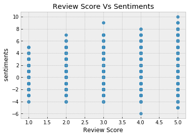

```python
#Draw a scatter plot
plt.scatter(x= review_score, y = sentiments)

#Add labels and title
plt.xlabel("Review Score")
plt.ylabel(" sentiments")
plt.title("Review Score Vs Sentiments")


plt.show()
```

That doesn't look like a useful plot.  
Repeat by dumping average sentiment in review score bin.

```python
#Create review bin
rate_1 = []
rate_2 = []
rate_3 = []
rate_4 = []
rate_5 = []
```

```python
feel_score = 0

for i in range (len(review_text)):
    #Divide the string into a list of words in case one positive word is used more than once
    sep_words = re.sub("[^\w]", " ", str(review_text[i])).split()
    #Compare word for word if the sentiment is good
    for k in range(len(sep_words)):
        for j in range(len(neg_word)):
            if neg_word[j] == sep_words[k]:
                feel_score -= 1
        for m in range(len(pos_word)):
            if pos_word[m] == sep_words[k]:
                feel_score += 1
    #Normalize the feel score over the length of the review
    feel_score = feel_score/len(sep_words)
    if review_score[i] == 1:
        rate_1.append(feel_score)
    elif review_score[i] == 2:
        rate_2.append(feel_score)
    elif review_score[i] == 3:
        rate_3.append(feel_score)
    elif review_score[i] == 4:
        rate_4.append(feel_score)
    elif review_score[i] == 5:
        rate_5.append(feel_score)
    #reset feel score for next iteration
    feel_score = 0
```

```python
#Store sentimetns in array
feels_tick = np.array([rate_1, rate_2, rate_3, rate_4, rate_5])
```

```python
feels_mean = []
for i in range(len(feels_tick)):
    feels_mean.append(np.mean(feels_tick[i]))
```

```python
feels_mean
```

```
[0.425719490690636,
 0.572512114101063,
 0.6573855761204245,
 0.9029908132600347,
 1.1326611422036332]
```

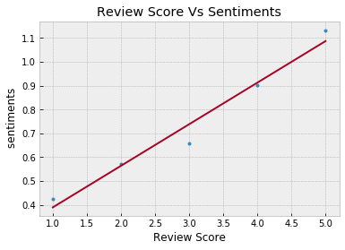

```python
from numpy.polynomial.polynomial import polyfit

#fit the data
b, m = polyfit(x = rating_bin, y = feels_mean, deg= 1)

#Draw a scatter plot
plt.plot(rating_bin, feels_mean, '.')
#draw the fit
plt.plot(rating_bin, b + m * rating_bin, '-')

#Add labels and title
plt.xlabel("Review Score")
plt.ylabel(" sentiments")
plt.title("Review Score Vs Sentiments")


plt.show()
```

As expected, review score is positively correlated to positive sentiment.  
Note that even among very low reviews, the sentiment is still positive which means that our negative words list is probably defficient. It could also mean that those who love a product can be more verbose if asked to describe their experience.